# Finishing Confidence Intervals

Albert Y. Kim

Fri Dec 3, 2016

Load the familiar data again, removing individuals with no listed height

```r
library(mosaic)
library(dplyr)
library(ggplot2)
library(okcupiddata)
data(profiles)
profiles <- profiles %>%
  filter(!is.na(height))
```

## Learning Checks

- Let’s **pretend** we don’t know the true mean mu = 68.3 inches
- Using the `resample()` function, take a **single sample** (without replacement) of size $n=50$ of 50 OkCupid users’ heights `profiles$height`. Assign this to an object `sample_50`.
- Using the `mean()`, `sd()`, and `sqrt()` functions, compute one confidence interval for mu.
- Did your net catch the fish?

## LC1: A Single Sample

```r
set.seed(76)
sample_50 <- resample(profiles$height, size=50, replace = FALSE)
```

## LC2: A 95% CI

```r
xbar <- mean(sample_50)
s <- sd(sample_50)
n <- length(sample_50)
c(xbar, s, n)
```

```
## [1] 68.340000  4.688719 50.000000
```

```r
c(xbar -2*s/sqrt(n), xbar +2*s/sqrt(n))
```

```
## [1] 67.01383 69.66617
```

Our 95% CI is
$$\left(\overline{x} - 2 SE, \overline{x} + 2 SE\right) =\left(\overline{x} - 2 \frac{s}{\sqrt{n}}, \overline{x} + 2 \frac{s}{\sqrt{n}}\right) = \left(67.01, 69.67\right)$$

## Long-Run Performance of CI

**Back to theoretical/rhetorical land** Let’s repeat the following procedure 100 times:

1. Take a sample of size $n=50$
2. Compute the 95% CI based on $\overline{x}$, $s$, $\sqrt{n}$
3. See if we caught the fish

Here are the (random) results:

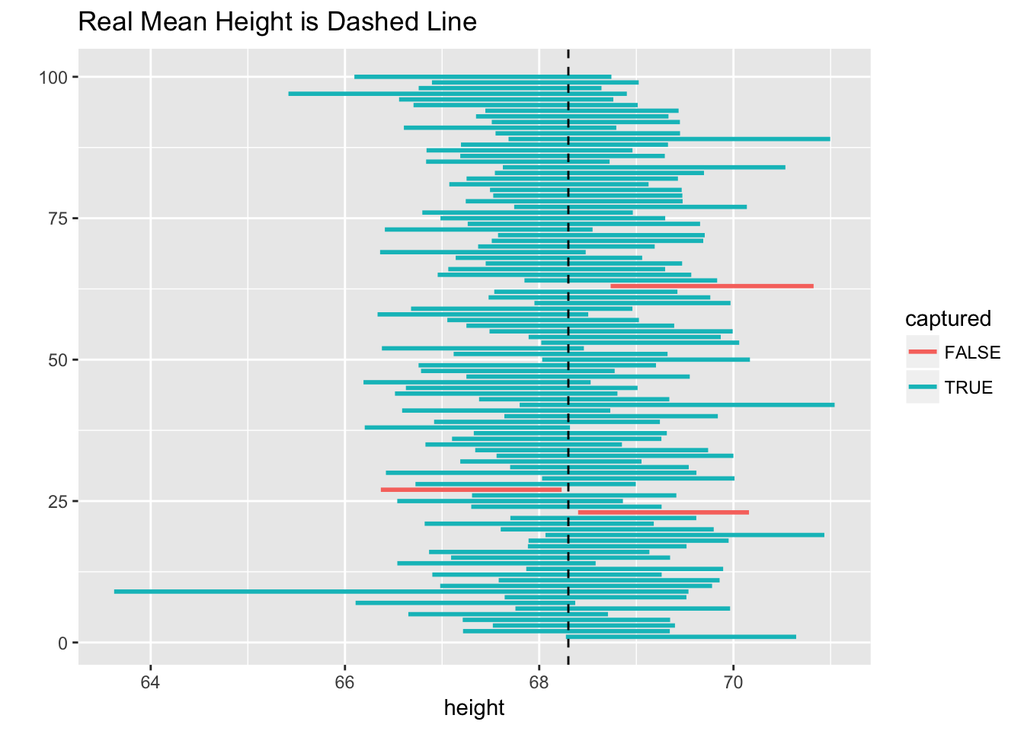

Our net missed the fish 3 times! On average, it will miss it 5% of the time.

## Correct Interpretation of Original CI

So the correct interpretation of our original 95% confidence interval (67.01, 69.67)

- **IS**: the procedure that generated the CI (67.01, 69.67) is **95% reliable**. i.e. 95% of the time it will get it right
- **IS NOT**: the probability that (67.01, 69.67) contains the true mean height is 95%.  
  i.e. the probability is either 1 or 0: either is does or doesn’t.